# Simple Linear Regression

### 13.0.3 Homoscedasticity

Last but not least, the homoscedasticity assumption is fourth on the list. This one sounds complicated but knowing the literal meaning of the term helps. **Homoscedasticity means having the same scatter.** Scatter plots come to the rescue once again when checking for homoscedasticity.

Returning to the scatter plot of fitted values versus residuals, there should be constant variance along the values of the dependent variable. This assumption is true if you notice no clear pattern in a scatter plot. Sometimes you’ll hear this described as a random cloud of data points. But for example, if you observe a cone-shaped pattern, then the assumption is invalid.

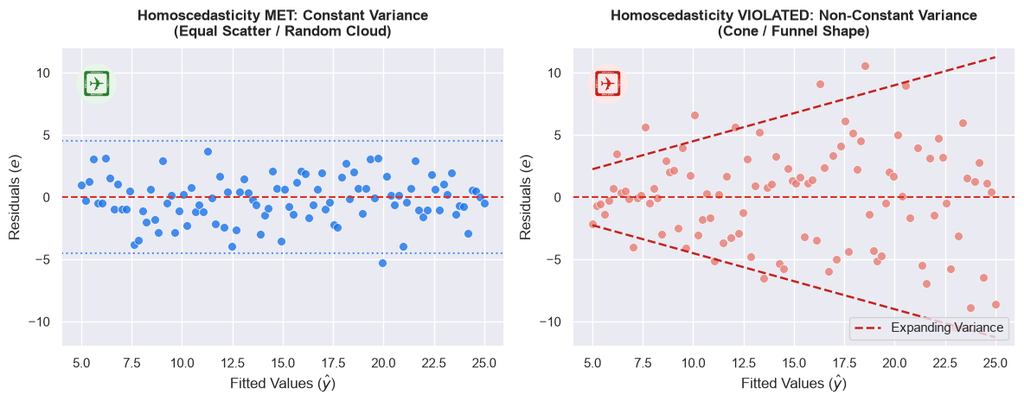

Figure 3: Checking Homoscedasticity: Constant residual variance vs. expanding cone shape.

```python
import matplotlib.pyplot as plt
import numpy as np
import seaborn as sns

np.random.seed(42)
n = 100

# Apply Seaborn theme for course consistency
sns.set_theme(style="darkgrid")

# Fitted values for both plots
fitted_values = np.linspace(5, 25, n)

# 1. Homoscedasticity (Constant Variance) -> Random Cloud / Equal Spread
res_homo = np.random.normal(0, 2, n)

# 2. Heteroscedasticity (Non-constant Variance) -> Cone / Funnel Shape
# Noise scale increases linearly with fitted values
sigma = 0.3 * fitted_values
res_hetero = np.random.normal(0, sigma, n)

fig, axes = plt.subplots(1, 2, figsize=(12, 4.8), dpi=100)

# Left Plot: Homoscedasticity (Seaborn)
sns.scatterplot(
    x=fitted_values, y=res_homo, color="#1a73e8", alpha=0.8, s=50, ax=axes[0]
)
axes[0].axhline(0, color="#d93025", linestyle="--", linewidth=1.5)

# Parallel variance bands
axes[0].axhline(4.5, color="#1a73e8", linestyle=":", alpha=0.7, linewidth=1.5)
axes[0].axhline(-4.5, color="#1a73e8", linestyle=":", alpha=0.7, linewidth=1.5)

axes[0].set_title(
    "Homoscedasticity MET: Constant Variance\n(Equal Scatter / Random Cloud)",
    fontsize=12,
    fontweight="bold",
    pad=10,
)
axes[0].set_xlabel("Fitted Values ($\hat{y}$)")
axes[0].set_ylabel("Residuals ($e$)")
axes[0].set_ylim(-12, 12)

# Green Check Badge
axes[0].text(
    0.08,
    0.88,
    "✓",
    color="#2e7d32",
    fontsize=22,
    fontweight="bold",
    transform=axes[0].transAxes,
    ha="center",
    va="center",
    bbox=dict(
        boxstyle="circle,pad=0.2", facecolor="#e8f5e9", edgecolor="none"
    ),
)

# Right Plot: Heteroscedasticity (Seaborn)
sns.scatterplot(
    x=fitted_values, y=res_hetero, color="#e67c73", alpha=0.8, s=50, ax=axes[1]
)
axes[1].axhline(0, color="#d93025", linestyle="--", linewidth=1.5)

# Cone boundary lines
axes[1].plot(
    fitted_values,
    0.45 * fitted_values,
    color="#c5221f",
    linestyle="--",
    linewidth=1.8,
    label="Expanding Variance",
)
axes[1].plot(
    fitted_values,
    -0.45 * fitted_values,
    color="#c5221f",
    linestyle="--",
    linewidth=1.8,
)

axes[1].set_title(
    "Homoscedasticity VIOLATED: Non-Constant Variance\n(Cone / Funnel Shape)",
    fontsize=12,
    fontweight="bold",
    pad=10,
)
axes[1].set_xlabel("Fitted Values ($\hat{y}$)")
axes[1].set_ylabel("Residuals ($e$)")
axes[1].set_ylim(-12, 12)
axes[1].legend(loc="lower right")

# Red X Badge
axes[1].text(
    0.08,
    0.88,
    "✗",
    color="#c5221f",
    fontsize=22,
    fontweight="bold",
    transform=axes[1].transAxes,
    ha="center",
    va="center",
    bbox=dict(
        boxstyle="circle,pad=0.2", facecolor="#fce8e6", edgecolor="none"
    ),
)

plt.tight_layout()
plt.show()
```

#### Breakdown of the Visuals

- **Etymology:** *Homo* = Same, *Scedasticity* = Scatter/Spread. So **Homoscedasticity** simply means “Equal Scatter.”
- **Left Plot (Met):** The vertical spread of the residuals remains uniform from left to right inside parallel boundaries. The residual variance does not depend on the predicted value $\hat{y}$.
- **Right Plot (Violated / Heteroscedasticity):** The vertical spread expands into a **cone or funnel shape** as fitted values grow larger. This non-constant variance often occurs when working with monetary data or scaling growth, and can usually be fixed by applying a logarithmic transformation ($\ln(y)$) to the target variable.

Linearity, normality, independent observations and homoscedasticity are the four assumptions of a simple linear regression. Before moving ahead, don’t feel like you need to memorize all of this material right now. Remember, data analysis is an iterative process. You can go back to these concepts, check to see how the assumptions aligned with your data, and then move forward with the regression process. You will have plenty of opportunities to practice and hone your skills throughout this course. Now let’s apply everything you’ve learned here and try it out on a dataset using Python.

# 14 The four main assumptions of simple linear regression

In this reading, you will review the four main assumptions of simple linear regression, how to check that the assumptions are met, and what to do if an assumption is not met. You can use the additional resources to replicate the graphs and explore assumptions on your own. If there are any terms not defined in this reading, refer to the glossary of terms available throughout the course at the end of each module. This reading will cover:

- Simple linear regression assumptions
- How to check the validity of the assumptions
- What to do if an assumption is violated

## 14.1 Simple linear regression assumptions

To recap, there are four assumptions of simple linear regression:

1. **Linearity:** Each predictor variable (Xi) is linearly related to the outcome variable (Y).
2. **Normality:** The errors are normally distributed.*
3. **Independent Observations:** Each observation in the dataset is independent.
4. **Homoscedasticity:** The variance of the errors is constant or similar across the model.*

*Note on errors and residuals

This course has rather interchangeably used the terms “errors” and “residuals” in connection with regression. You may see this in other online resources and materials throughout your time as a data professional. In actuality, there is a difference:

- **Residuals** are the difference between the predicted and observed values. You can calculate residuals after you build a regression model by subtracting the predicted values from the observed values.
- **Errors** are the natural noise assumed to be in the model.
- Residuals are used to estimate errors when checking the normality and homoscedasticity assumptions of linear regression.

## 14.2 How to check the validity of the assumptions

As previously reviewed, many of the simple linear regression assumptions can be checked through data visualizations. Some assumptions can be checked before a model is built, and others can only be checked after the model is constructed, and predicted values are calculated.

### 14.2.1 Linearity

In order to assess whether or not there is a linear relationship between the independent and dependent variables, it is easiest to create a scatterplot of the dataset. The independent variable would be on the x-axis, and the dependent variable would be on the y-axis. There are a number of different Python functions that you can use to read in the data and to create a scatterplot. Some packages used for data visualizations include Matplotlib, seaborn, and Plotly. Testing the linearity assumption should occur before the model is built.

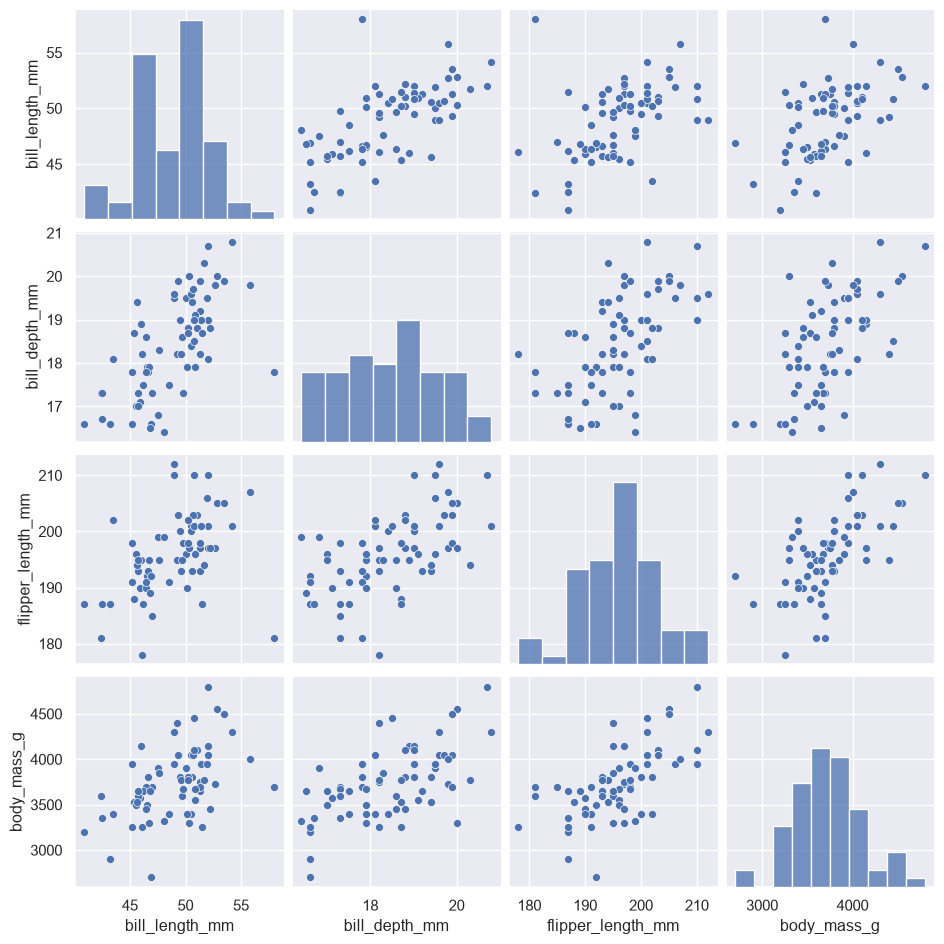

```python
import pandas as pd
import seaborn as sns
penguins = pd.read_csv(r'Datasets/penguins.csv')
chinstrap_penguins = penguins[penguins['species'] == 'Chinstrap']

# Create pairwise scatterplots of Chinstrap penguins data
sns.pairplot(chinstrap_penguins)
```

### 14.2.2 Normality

The normality assumption focuses on the errors, which can be estimated by the residuals, or the difference between the observed values in the data and the values predicted by the regression model. For that reason, the normality assumption can only be confirmed after a model is built and predicted values are calculated. Once the model has been built, you can either create a QQ-plot to check that the residuals are normally distributed, or create a histogram of the residuals. Whether the assumption is met is up to some level of interpretation.

**Quantile-quantile plot** The quantile-quantile plot (Q-Q plot) is a graphical tool used to compare two probability distributions by plotting their quantiles against each other. Data professionals often prefer Q-Q plots to histograms to gauge the normality of a distribution because it’s easier to discern whether a plot adheres to a straight line than it is to determine how closely a histogram follows a normal curve. Here’s how Q-Q plots work when assessing the normality of a model’s residuals:

1. **Rank-order the residuals.** Sort your $n$ residuals from least to greatest. For each one, calculate what percentage of the data falls at or below this rank. These are the $n$ quantiles of your data.
2. **Compare to a normal distribution.** Divide a standard normal distribution into $n+1$ equal areas (i.e., slice it $n$ times). If the residuals are normally distributed, the quantile of each residual (i.e., what percentage of the data falls below each ranked residual) will align closely with the corresponding $z$-scores of each of the $n$ cuts on the standard normal distribution (these can be found in a normal $z$-score table or, more commonly, using statistical software).
3. **Construct a plot.** A Q-Q plot has the known quantile values of a standard normal distribution along its x-axis and the rank-ordered residual values on its y-axis. If the residuals are normally distributed, the quantile values of the residuals will correspond with those of the standardized normal distribution, and both will increase linearly. If you first standardize your residuals (convert to $z$-scores by subtracting the mean and dividing by the standard deviation), the two axes will be on identical scales, and, if the residuals are indeed normally distributed, the line will be at a 45° angle. However, standardizing the residuals is not a requirement of a Q-Q plot. In either case, if the resulting plot is not linear, the residuals are not normally distributed.

In the following figure, the first Q-Q plot depicts data that was taken from a normal distribution. It forms a line when plotted against the quantiles of a standard normal distribution. The second plot depicts data that was drawn from an exponential distribution. The third plot uses data drawn from a uniform distribution. Notice how the second and third plots don’t adhere to a line.

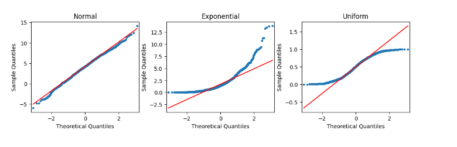

#### How to code a Q-Q plot

Thankfully, you don’t have to manually perform the steps outlined previously. There are computing libraries to handle that. One way to create a Q-Q plot is to use the statsmodels library. If you import **statsmodels.api**, you can use the [qqplot()](https://www.statsmodels.org/stable/generated/statsmodels.graphics.gofplots.qqplot.html) function directly. The example below uses the residuals from a **statsmodels ols** model object. The model regresses penguins’ flipper length on their bill depth (Y on X).

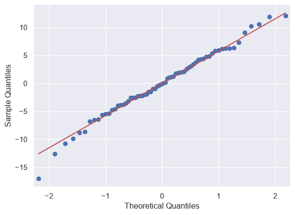

```python
import statsmodels.api as sm
import matplotlib.pyplot as plt

#drop na values

chinstrap_penguins = chinstrap_penguins.dropna()
flipper_length = chinstrap_penguins.flipper_length_mm
bill_depth = chinstrap_penguins.bill_depth_mm

model = sm.OLS(flipper_length, sm.add_constant(bill_depth))
results = model.fit()
residuals = results.resid
fig = sm.qqplot(residuals, line = 's')
plt.show()
```

And here is a histogram of the same data:

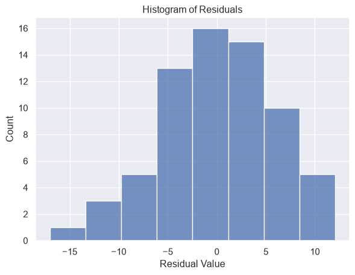

```python
fig = sns.histplot(residuals)
fig.set_xlabel("Residual Value")
fig.set_title("Histogram of Residuals")
plt.show()
```

### 14.2.3 Independent Observations

Whether or not observations are independent is dependent on understanding your data. Asking questions like:

How was the data collected?

What does each data point represent?

Based on the data collection process, is it likely that the value of one data point impacts the value of another data point?

An objective review of these questions, which would include soliciting insights from others who might notice things you don’t, can help you determine whether or not the independent observations assumption is violated. This in turn will allow you to determine your next steps in working with the dataset at hand.

### 14.2.4 Homoscedasticity

Like the normality assumption, the homoscedasticity assumption concerns the residuals of a model, so it can only be evaluated after a regression model has already been constructed. A scatterplot of the fitted values (i.e., the model’s predicted Y values) versus the residuals can help determine whether the homoscedasticity assumption is violated.

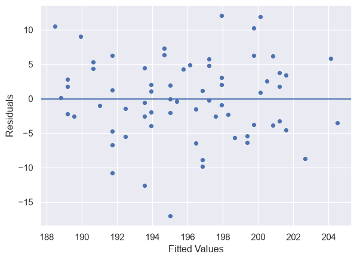

```python
import matplotlib.pyplot as plt

#get the fitted values from the model
fitted_values = results.fittedvalues

fig = sns.scatterplot(x=fitted_values, y=residuals)
fig.axhline(0)
fig.set_xlabel("Fitted Values")
fig.set_ylabel("Residuals")
plt.show()
```

## 14.3 What to do if an assumption is violated

Now that you’ve reviewed the four assumptions and how to test for their violations, it’s time to discuss some common next steps you can take once an assumption is violated. Keep in mind that if you transform the data, this might change how you interpret the results. Additionally, if these potential solutions don’t work for your data, you have to consider trying a different kind of model.

For now, focus on a few essential approaches to get you started!

### 14.3.1 Linearity:

Transform one or both of the variables, such as taking the logarithm.

For example, if you are measuring the relationship between years of education and income, you can take the logarithm of the income variable and check if that helps the linear relationship.

### 14.3.2 Normality:

Transform one or both variables. Most commonly, this would involve taking the logarithm of the outcome variable.

When the outcome variable is right skewed, such as income, the normality of the residuals can be affected. So, taking the logarithm of the outcome variable can sometimes help with this assumption.

If you transform a variable, you will need to reconstruct the model and then recheck the normality assumption to be sure. If the assumption is still not satisfied, you’ll have to continue troubleshooting the issue.

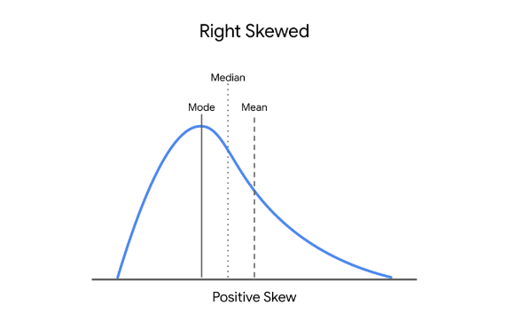

### 14.3.3 Independent observations

Take just a subset of the available data.

If, for example, you are conducting a survey and get responses from people in the same household, their responses may be correlated. You can correct for this by just keeping the data of one person in each household.

Another example is if you are collecting data over a time period. Let’s say you are researching data on bike rentals. If you collect your data every 15 minutes, the number of bikes rented out at 8:00 a.m. might correlate with the number of bikes rented out at 8:15 a.m. But, perhaps the number of bikes rented out is independent if the data is taken once every 2 hours, instead of once every 15 minutes.

### 14.3.4 Homoscedasticity

Define a different outcome variable.

If you are interested in understanding how a city’s population correlates with the number of restaurants in a city, you know that some cities are much more populous than others. You can then redefine the outcome variable as the ratio of population to restaurants.

Transform the Y variable.

As with the above assumptions, sometimes taking the logarithm or transforming the Y variable in another way can potentially fix inconsistencies with the homoscedasticity assumption.

## 14.4 Key takeaways

- There are four key assumptions for simple linear regression: linearity, normality, independent observations, and homoscedasticity.
- There are different ways to check the validity of each assumption. Some assumptions can be checked before the model is built, while some can be checked after the model is built.
- There are ways to work with the data that can correct for violations of model assumptions.
- Changing the variables will change the interpretation.
- If the assumptions are violated, even after data transformations, you should consider other models for your data.

## 14.5 Resources for more information

- [Download the seaborn penguins dataset here](https://raw.githubusercontent.com/mwaskom/seaborn-data/master/penguins.csv)
- More information about the penguins dataset: [Introduction to Palmer penguins](https://allisonhorst.github.io/palmerpenguins/articles/intro.html)
- More information about Q-Q plots: [Normal Quantile-Quantile Plots (video from jbstatistics)](https://www.youtube.com/watch?v=X9_ISJ0YpGw)

# 15 Evaluate a linear regression model

So far, we’ve used pace to think like a data professional as we address the penguin problem at our local zoo. We planned by thinking through the problem and sub setting the available data appropriately. How can we better understand the relationship between penguin anatomy and their body mass. In the analyzed stage we performed EDA and check model assumptions. Then moving on to the construct stage. As a reminder, there are two parts. We built our model and were able to pull out some parameter estimates.

Now we’re going to focus on the next step of the construct phase: **model evaluation**.

Model evaluation is an important practice in data analysis. Careful evaluation and interpretation of your regression model helps you understand its performance and accuracy. To start, let’s revisit the results from our regression model.

Based on the summary results, you know that Ols has determined that the best fit line has an intercept of negative 1707.29 and a slope of 141.19. But randomness and unpredictability are characteristics of every regression model that make it difficult to predict outcomes with 100% certainty. After all, there is still a difference between our observed and predicted values.

You’ve just found the model that you are most certain about. To explore the notion of uncertainty further, let’s turn our attention to the rest of the Ols summary table rose about the intercept and bill length.

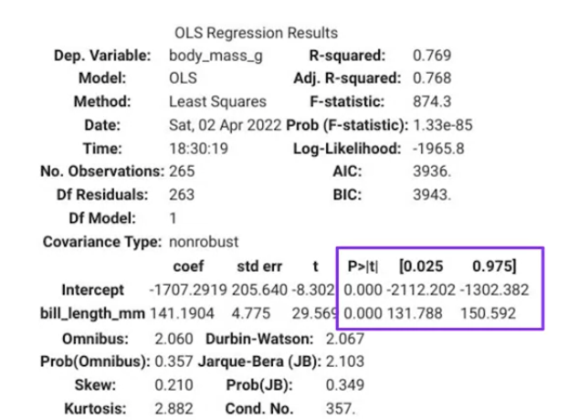

There is a column labeled $P>|t|$ . This indicates the $p$-value associated with the coefficient estimates. The two columns to the right of the $p$-value column indicate a 95% confidence interval around the coefficient estimates. **When evaluating simple linear regression results, you’ll focus less on the intercept row and more on the row involving your independent variables of interest**. In this case, that’s bill length.

So you can say that the coefficient estimates for bill length is 141.19 with a p value of 0.0 and a confidence interval from 131.788 to 150.592. Previously, when you learned about hypothesis tests, confidence intervals were defined as a range of values that described the uncertainty surrounding an estimate. In the case of linear regression, we are estimating parameters. So **a 95% confidence interval means that interval has a 95% chance of containing the true parameter value of the slope**.

What if the slope and intercept were slightly different? Well, let’s draw out a few different lines on our plot with slightly different slopes and intercepts all within our confidence intervals.

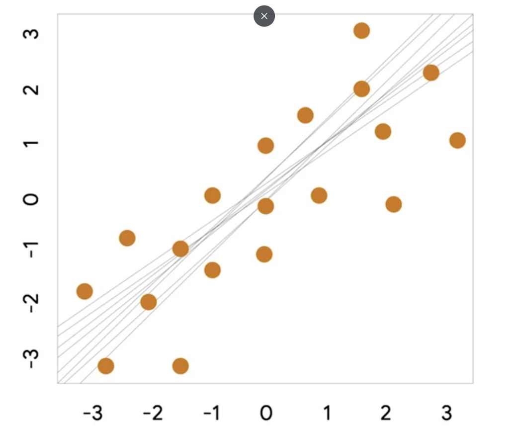

We get a region around the regression line that is tight around the center and fans out a bit towards either end of the line.

This shape may appear familiar. You plotted it previously using Seaborn’s reg plot function. These lines make up the shaded region that was around the regression line.

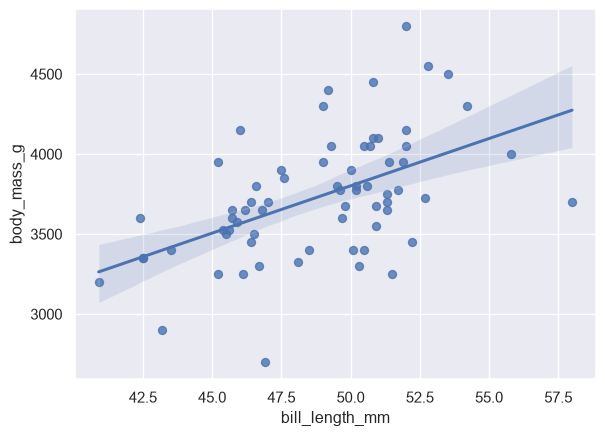

```python
sns.regplot(x="bill_length_mm", y = "body_mass_g", data = chinstrap_penguins)
```

Essentially the confidence interval around the parameter estimates reveal what we call a confidence band. A confidence band is the area surrounding the line that describes the uncertainty around the predicted outcomes at every value of X. Typically expressed as a shaded region around the best fit line on a scatter plot. A confidence band reveals the confidence interval for each point on a regression line.

Confidence bands are simply another way to report your findings responsibly. Simple linear regression is a powerful addition to any data professional’s toolbox. Whether you are analyzing the financial impact of price increases to a streaming service or your forecasting sales for a fashion boutique, regression analysis can help you make discoveries and understand the relationship behind the data. But we must remember data is noisy and results can be uncertain. When using regression models like simple linear regression, even the best data doesn’t tell a complete story. As a data analytics professional, you should always aim not only to evaluate the performance and accuracy of your models, but also to report uncertainty. Communicating about confidence intervals and confidence bands is part of being a responsible data professional.

These metrics will also help you understand how well the models can tell the story behind the data.

# 16 Interpret measures of uncertainty in regression

# 17 Goal of Reading

In this reading, we will continue exploring uncertainty in regression analysis, specifically through confidence intervals, confidence bands, and p-values. Together, we will:

- Review key concepts
- Discuss how to interpret measures of uncertainty
- Review sample graphs

# 18 Review of Concepts

Recall that we can represent a simple linear regression line as y=β0+β1X

There is one residual, also known as the difference between the predicted and actual value, for each data point in the dataset used to construct the model. We can then quantify how uncertain the entire model is through a few measures of uncertainty:

- **Confidence intervals** around beta coefficients
- **P-values** for the beta coefficients
- **Confidence band** around the regression line

You can refer to the glossary of terms to check any key terms and definitions, but we’ve provided the two key terms here:

- **Confidence interval:** a range of values that describes the uncertainty surrounding an estimate
- **P-value:** the probability of observing results as extreme as those observed when the null hypothesis is true

# 19 Interpreting Uncertainty

Let’s first revisit the summary of results from the linear regression model we created together in prior videos:

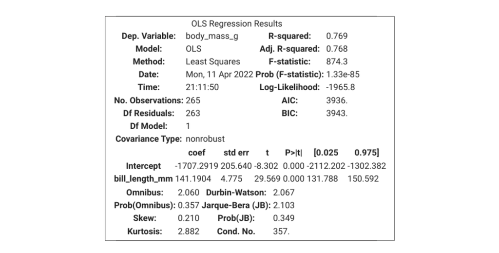

According to the simple linear regression model we built, β_1 is 141.1904. So for every one-millimeter increase in the bill length of a penguin, we would expect a penguin to have about 141.1904 more grams in body mass. The estimate has a $p$-value of 0.000, which is less than 0.05, meaning that the coefficient is “statistically significant.” Additionally our estimate has a 95% confidence interval of 131.788 and 150.592. Let’s review these short sentences a bit more.

Previously you may have learned about $p$-values and confidence intervals within the context of hypothesis testing. Even though it may seem unintuitive, even in regression analysis we are testing hypotheses.

### 19.0.1 P-values

When running regression analysis, you want to know if X is really correlated with Y or not. So we do a hypothesis test on the regression results. In regression analysis, for each beta coefficient, we are testing the following set of null and alternative hypotheses:

- H₀ (null hypothesis): β_1=0
- H₁ (alternative hypothesis): β_1≠0

In our example, because the $p$-value is less than 0.05, we can reject the null hypothesis that β_1, and state that the coefficient is statistically significant, which means that a difference in bill length of a penguin is truly correlated with a difference in body mass.

### 19.0.2 Confidence Intervals

Each beta coefficient also has a confidence interval associated with its estimate. A 95% interval means the interval itself has a 95% chance of containing the true parameter value of the coefficient. So there is 5% chance that our confidence interval [131.788, 150.592] does not contain the true value of β_1. More precisely, this means that if you were to repeat this experiment many times, 95% of the confidence intervals would contain the true value of β_1.

But, since there is uncertainty in both of the estimated beta coefficients, then the estimated y values also have uncertainty. This is where confidence bands become useful.

# 20 Example Graph

- **Confidence band:** the area surrounding the line that describes the uncertainty around the predicted outcome. You can think of the confidence band as representing the confidence interval surrounding each point estimate of y. Since there is uncertainty at every point in the line, we use the confidence band to summarize the confidence intervals across the regression model. The confidence band is always narrowest towards the mean of the sample and widest at the extremities.

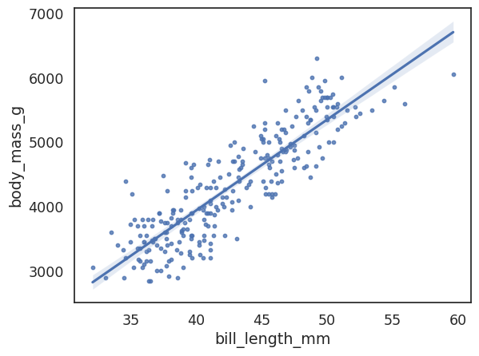

# 21 Key Takeaways

- Regression analysis utilizes **estimation** techniques, so there is always uncertainty around the predictions.
- We can measure uncertainty using confidence intervals, p-values, and confidence bands.
- For every coefficient estimate, we are testing the hypothesis that the coefficient equals 0.

# 22 Model evaluation metrics

Up to this point, we’ve progressed through the plan and analyze phases of the pace framework for regression modeling. We’ve even started the construct phase by actually building a linear regression model. I’m excited to continue guiding you through model evaluation. We’re getting so close to the execute phase, where you share the stories behind the data you’re studying. Using a variety of evaluation metrics, supports data professionals, confidence in the insights produced by their analysis. These metrics are key to responsible communication of results. If models are inaccurate or imprecise, decisions made based on those insights may also be inaccurate.

Three metrics you might encounter are **R-squared**, **mean squared error** also called MSE, and **mean absolute error** or MAE.

The main metric that academics researchers and data professionals use when evaluating regression models is called the **coefficient of determination** or **R-squared**. So that’s what we’ll focus on.

You may have noticed that in the output from OLS model you previously built, there was a part of the output labeled R-squared. This is what we’re talking about.

R-squared or the coefficient of determination, measures the proportion of variation in the dependent variable, Y, explained by the independent variables, X.

To explain this metric more thoroughly, let’s think through the example about penguins and linear regression again.

You identified a linear relationship between the penguins bill length in millimeters, and the penguins body mass in grams. Based on your regression analysis, you found the best fit line, body mass and grams equals -1,707.30 plus 141.19 times bill length. But the data points just cluster around this best fit line. Many of the data points are actually not on the line. This means that bill length only accounts for some of the changes in body mass. R-squared helps data professionals determine how much of the variation in the X variable explains the variation in the Y variable.

At most R-squared can equal 1, which would mean that X explains 100% of the variance and Y. If R-squared equals 0, then that would mean X explains 0% of the variance in Y.

The OLS summary table shows the model has an R-squared of 0.769. This means that bill length explains about 77% of the variance in body mass. There is still about 23% of the variance of body mass that is unexplained by the model.

This variance might be due to other factors or natural unexplained differences from penguin to penguin. There is no benchmark value that R-squared has to equal. But in general, **the higher R-squared the better**, because it adds validity to any recommendation you make based on your analysis.

R-squared is a useful metric that can help you evaluate your model. But there are also processes that help strengthen the evaluation of a model.

Typically when we have a data set, we use at least part of the data set to build and test the regression model. The computer uses the data to calculate a measure of difference between the actual and predicted values, such as sum of squared residuals. Then based on the computer’s calculations, it can find the best line. But sometimes we want our model to be good at generating predictions for data we haven’t collected, or that doesn’t exist yet.

For example, let’s return to the penguins at the local zoo. They welcomed a new group of penguins to their flightless bird habitat. It would be helpful to have a sense of how the new penguins structural measurements relates to their body mass. So in those cases we want to know how the model we built performs on the data it learned from, and how the model performs on data it hasn’t experienced yet.

In this case we’ll need to save a hold-out sample before we build the model. **A hold-out sample is a random sample of observed data that is not used to fit the model**. Then you can evaluate how well the model fits the data used to build the model, and you can evaluate how well the model fits the hold-out sample. We’ve covered a lot of different ways you might evaluate linear regression model.

R-squared and hold-out samples will serve you in many cases, allowing you to confidently share the insights you’ve discovered. I’m excited to discuss the execute phase, and how to communicate model findings soon.

In this reading, we’ll provide a more comprehensive overview about evaluation metrics for simple linear regression. In a prior video we covered R², and mentioned a few other metrics, MAE and MSE. In this reading, we will review the metrics we’ve previously mentioned, and introduce a few more as well that you may encounter throughout your career as a data professional.

## 22.1 Review of R², MSE, and MAE

The main evaluation metric for linear regression is R², or the coefficient of determination.

## 22.2 R²: The coefficient of determination

**R²** measures the proportion of variation in the dependent variable, Y, explained by the independent variable(s), X.

- This is calculated by subtracting the sum of squared residuals divided by the total sum of squares from 1.

$$R^2 =1-\frac{\text{Sum of squared residuals (SSR)}}{\text{Total Sum of Squares (TSS)}}$$

The **Total Sum of Squares** measures the distance between actual data points ($Y$) and the **baseline average line** ($\bar{Y}$). It quantifies the total variance inherent in your outcome variable before you even fit a regression model.

$$\text{Total Sum of Squares (TTS)} = \sum^n_{i=1}(Y_i - \bar Y)^2$$

Imagine the total variation ($TSS$) in penguin beak lengths equals **100 units** of randomness:

- **Scenario A (A useless model):**
  - You predict beak length using a variable that has nothing to do with penguins (like today’s stock market index).
  - Your line explains nothing, so your leftover errors ($SSR$) are still **100 units**.
  - Fraction of failure: $\frac{SSR}{TSS} = \frac{100}{100} = 1.0$ (100% unexplained error).
  - $R^2 = 1 - 1.0 = \mathbf{0.0}$ (**0% explained**).
- **Scenario B (A strong model):**
  - You predict beak length using body mass ($X$).
  - Body mass explains a lot, so your leftover errors ($SSR$) drop down from 100 units to **30 units**.
  - Fraction of failure: $\frac{SSR}{TSS} = \frac{30}{100} = 0.30$ (30% unexplained error remains).
  - $R^2 = 1 - 0.30 = \mathbf{0.70}$ (**70% explained**).
- **Scenario C (A perfect imaginary model):**
  - Every single penguin falls directly on the line. Residuals ($SSR$) = **0 units**.
  - Fraction of failure: $\frac{0}{100} = 0.0$.
  - $R^2 = 1 - 0.0 = \mathbf{1.0}$ (**100% explained**).

The Big Picture

The formula $1 - \frac{SSR}{TSS}$ simply flips the question:

Instead of asking *“What fraction of the total randomness did my model fail to predict?”* ($\frac{SSR}{TSS}$), subtracting it from **1** asks *“What fraction of the total randomness did my model successfully eliminate?”* ($R^2$).

R² ranges from 0 to 1. So, if a model has an R² of 0.85, that means that the X variables explain about 85% of the variation in the Y variable. Although R² is a highly interpretable and commonly used metric, you may also encounter mean squared error (MSE) and mean absolute error (MAE) when R² is insufficient in evaluating model performance.

## 22.3 MSE: Mean squared error

**MSE (mean squared error)** is the average of the squared difference between the predicted and actual values.

**Mean Squared Error (MSE)** is simply the **Sum of Squared Errors (SSE)**—also called $SSR$—divided by the total number of observations ($n$).

$$\text{MSE} = \frac{\text{SSE}}{n} = \frac{\sum\_{i=1}\^{n} (y_i - \hat{y}\_i)\^2}{n}$$

- Because of how MSE is calculated, MSE is very sensitive to large errors.

Why Have Both?

SSE ($SSR$): Gives you the total cumulative error across all data points. The problem with SSE is that as your sample size ($n$) grows larger, your total SSE automatically gets bigger, even if your model predictions aren’t getting any worse.

MSE: Gives you the average squared error per observation. By taking the mean, it normalizes the error so you can fairly compare model performance across datasets of different sizes (e.g., comparing a model trained on 100 penguins vs. 1,000 penguins).

(Note: In formal OLS regression, you will sometimes see MSE defined as $\frac{\text{SSE}}{n - p}$ where $p$ accounts for estimated model parameters to adjust for degrees of freedom, but in general data science practice, dividing by $n$ is standard!)

## 22.4 MAE: Mean absolute error

**MAE (mean absolute error)** is the average of the absolute difference between the predicted and actual values.

- If your data has outliers that you want to ignore, you can use MAE, as it is not sensitive to large errors.

Both metrics measure the average magnitude of model errors in unit terms, but they treat large mispredictions very differently because of their math.

### 22.4.1 The Mathematical Difference

| **Metric** | **Formula** | **What It Does to Errors** |
| --- | --- | --- |
| **MAE** | $\frac{1}{n} \sum \Vert{}y_i - \hat{y}_i\Vert{}$ | Treats all errors **linearly**. An error of 10 is simply twice as bad as an error of 5. |
| **MSE** | $\frac{1}{n} \sum (y_i - \hat{y}_i)^2$ | **Squares** errors before averaging. An error of 10 becomes $10^2 = 100$, which is **4 times worse** than an error of 5 ($5^2 = 25$). |

## 22.5 Other evaluation metrics

Beyond the three metrics listed above, you may also encounter [**AIC (Akaike information criterion) and BIC (Bayesian information criterion)**](https://machinelearningmastery.com/probabilistic-model-selection-measures/).

Lastly, there is **adjusted R²**, which will be addressed in more detail in upcoming videos. It is a variation of R² that accounts for having multiple independent variables present in a linear regression model.

## 22.6 Key takeaways

- There are many evaluation metrics to choose from with regard to simple linear regression.
- The most common evaluation metric you’ll encounter is probably R². But, there are times when R² is insufficient or inappropriate to use.
- Based on your experiences and the particulars of a metric, you can use your best judgment to select an appropriate metric to evaluate a regression model.

# 23 Interpret and present linear regression results

Earlier in the course, you build a regression model that passed all four of the assumptions for simple linear regression.

Residual plots confirmed a linear relationship and you are able to successfully evaluate the performance of the model using a few common metrics. Next, it’s onto the execute phase of the PACE framework, how exciting.

This is the point of the PACE framework when your ability to communicate is crucial. Together, we’re going to review interpreting the results of our regression model, exploring ways in which those insights can be translated into formal visualizations, and communicating a meaningful narrative with stakeholders. In one of my previous positions, I was brought on to help a newly launched mobile phone service provider reduce the amount of fraudulent orders they were receiving. After building out a model, it was time to present the model, insights, and recommendations to my stakeholders.

These folks were non-technical business partners so I knew that data-specific terminology wouldn’t interest them. As a matter of fact, it would be too technical and they would probably lose interest very quickly, which would cause lack of buy-in. What was important to my business partners was stopping fraudulent orders. So telling a story in a way where I succinctly articulated how many fraudulent orders the model would detect and how that translated to the bottom line resulted in the model being implemented immediately. I remember feeling so accomplished in that moment because after all the hard work of building the model, I was able to get the model into production. Once the model was in production, fraudulent orders dropped drastically.

Telling the right story to the right people takes time and practice. This is a skill that will continue to work on throughout our careers. It’s super important to know your audience and tailor your delivery and story in order to have the most impact. Enough about me, let’s return to the example that we’ve been exploring where you were working at a local zoo.

You were trying to understand the relationship between penguins’ structural measurements and their body mass. In the regression model you created, you observe a positive correlation between bill length and body mass of a group of penguins. Let’s use the results of that model to translate the statistical findings for stakeholders.

Regression model interpretation depends on coefficients and $p$-values. **Coefficients will determine how changes in the independent variable are associated with changes in the dependent variable**. **$p$-values demonstrate whether coefficients are statistically significant**. Recall that the slope is used to determine the amount you expect $y$ to increase or decrease per one unit increase of $x$.

Let’s go through the numbers yielded in the OLS summary table to gain a better understanding. Body mass equals intercept plus slope times bill length. The slope is positive 141.19 and the intercept is negative 1707.29. Next, let’s review the $p$-value. The coefficient for bill length has a $p$-value of 0.000.

**This** $p$**-value tests the null hypothesis that the coefficient is zero.**

If we observe a small $p$-value, the null hypothesis is likely false. We reject the null hypothesis and conclude that the coefficient is not zero, meaning that there is a strong relationship between $x$ and $y$.

It’s important to understand that the positive correlation between bill length and body mass you’ve observed does not necessarily reflect causation. Remember, causation describes a cause-and-effect relationship where one variable directly causes the other to change in a particular way. The positive correlation between bill size and mass could be the result of a variety of factors.

Even though we cannot speak to causation, we can still provide valuable insights about the penguins. Based on our regression analysis, we can say that for penguins with one millimeter more in bill length, their body mass is 141.19 grams more. These results are statistically significant with a $p$-value of 0.000, a confidence interval of [131.79-150.59], and an $R^2$ of 0.77.

By providing measures of uncertainty around our estimates, we’re responsibly reporting our results. Based on the interpretation of the numbers, you can contribute to the zoo community around you. Each person on the team at the zoo brings a variety of experiences and knowledge. The input from your colleagues adds richer detail to the story the model tells.

Without the informed perspectives of the other bird caretakers, the avian department would not be able to make a sound argument for an increase in food to maintain an adequate inventory that supports the penguins and other birds at the zoo.

When sharing insights as a data analytics professional, you need to make sure that your findings can be quickly understood and correctly interpreted. Communicating the context of your data is one way you can report it responsibly. For example, if your results only apply to a specific penguin population, make it clear that people should be cautious about extrapolating to larger or different groups of penguins. Data visualizations are excellent ways of making statistics relatable for others. Use caution when presenting terms like coefficients and $p$-values in your visualizations. Consider that not everyone will fully grasp the significance of these terms immediately.

There are many useful libraries like Matplotlib and Seaborn that can help create visualizations. Programs like Tableau, PowerPoint, or Google slides allow for creation of high-quality presentations to help you provide contexts that’s relevant to the business problem. Regardless of your visualization tool of choice, communicating with those around you is critical to your success at all points of the PACE process. As a data analytics professional, clear communication allows you and your work to have impact throughout your team and organization.

# 24 Correlation versus causation: Interpret regression results

In previous videos, you learned that correlation is not causation. In this reading, you will continue to explore the differences between correlation and causation so that you will be prepared to report regression results responsibly, honestly, and effectively.

## 24.1 What is correlation?

You might recall that there are two main kinds of correlation: positive and negative correlation.

- **Positive correlation** is a relationship between two variables that tend to increase or decrease together.
- **Negative correlation** is an inverse relationship between two variables, where when one variable increases, the other variable tends to decrease, and vice versa.

To generalize, **correlation** measures the way two variables tend to change together. There is a metric called the [Pearson correlation coefficient](https://docs.scipy.org/doc/scipy/reference/generated/scipy.stats.pearsonr.html) that ranges from -1 to 1 that can measure the relationship between two variables.

Note that correlation is just observational. Two variables can be correlated–they tend to change together without one variable causing the other variable to change. In fact, there is an entire website and book, [*Spurious Correlations*](https://www.tylervigen.com/spurious-correlations), devoted to documenting interesting and unexpected correlations between variables.

For example, here is a graph illustrating the correlation between total revenue generated by arcades and computer science doctorates awarded in the United States. Over time, computer science doctorates and arcade revenue increase at about the same rate. So, the graph definitely shows a correlation between the two variables, but it’s pretty hard to argue that one causes the other.

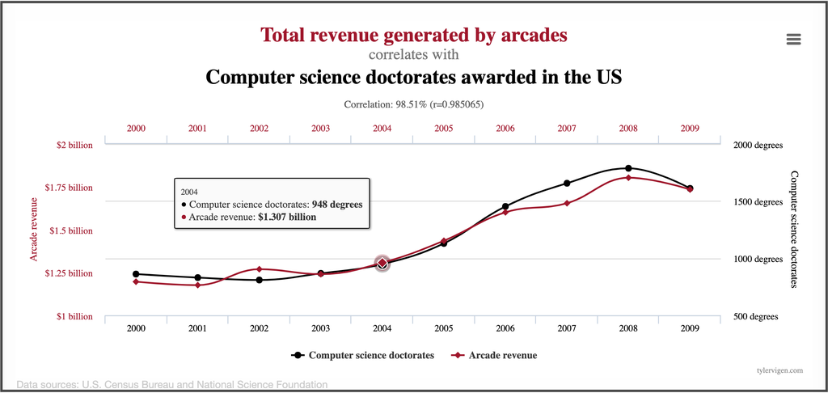

## 24.2 It’s difficult to claim causation

Previously you learned that **causation** describes a cause-and-effect relationship where one variable directly causes the other to change in a particular way. Although this is an intuitive definition, proving causation requires a lot of particular circumstances to be met.

To argue for causation between variables, in general, you must run a [**randomized controlled experiment**](https://www.urban.org/research/data-methods/data-analysis/quantitative-data-analysis/impact-analysis/experiments). The following are some key components of a proper randomized controlled experiment:

- You must control for every factor in the experiment.
- You must have a control group under certain conditions.
- You must have at least one treatment group under certain conditions.
- The difference(s) between the control and treatment groups must be observable and measurable.

Setting up a randomized controlled experiment is quite laborious and intensive. There are a number of requirements and factors not included in this reading, but there is a lot of information online and in academic research that you can explore on your own. Understanding the basics of causal claims allows you to responsibly report the results of your data analysis.

## 24.3 Correlation leads to interesting insights

When working as a data professional, you often do not have complete control of how the data is collected. You or your team might not be able to run a randomized controlled experiment. But, even if you cannot make causal claims, correlational research can still yield interesting results that have meaningful business implications.

### 24.3.1 Scenario 1: Optimizing athletic performance

Suppose a runner is training for a race. There are many ways to track health data—from built-in apps to paid-for apps. But, there are also so many factors that can contribute to the runner’s performance—how much water they drank, how sore their muscles are on a given day, the weather, how much sleep they got, what equipment they are using on race day, and the clothes they are wearing. It’s very hard to claim that any one factor would make or break their race time. But, over time, one might observe patterns in how sleep, soreness, water, clothing, and other factors tend to correlate with performance. This is why athletes can be so particular about brands of equipment, their diet, and pre-race day routines.

### 24.3.2 Claims you can make (correlation)

- When the runner drinks more water the day before a race, they tend to have more stamina.
- When the runner doesn’t run long distances the week before a race, they tend to feel better on race day.

### 24.3.3 Claims you cannot make (causation)

- Drinking more water the day before a race causes the runner to run faster.
- Not running long distances the week before a race causes the runner to run faster.

### 24.3.4 Scenario 2: Improving food quality

Perhaps you’re a new chef at a restaurant or you’re cooking for yourself or family. Every time you make a dish, there are a lot of variables: what pan was used, when the ingredients were purchased, if the ingredients are in season, and how hungry everyone was. Any one of these factors can change how “good” the dish is. But, this data is valuable regardless of causal claims. Over time, you can hone your cooking skills for this particular dish to ensure better food quality.

These are just two examples where gathering data to understand correlation between factors can drastically improve outcomes. The same principles can be applied on a larger scale, with big data, and in different industries, depending on the desired outcome you want to optimize.

### 24.3.5 Claims you can make (correlation)

- When I use fresher ingredients, the final dish tends to taste better.
- When I am very hungry, the final dish tends to taste better.

### 24.3.6 Claims you cannot make (causation)

- Using fresher ingredients makes the dish taste better.
- Being hungrier makes the dish taste better.

## 24.4 Key takeaways

- Claiming causation requires specific circumstances that are often not within your control.
- Correlation analyses are an incredibly useful tool for data professionals, and can provide interesting insights and actionable next steps.